# Gallery Visits January 17 2026

NWilson

2026-01-18

### The Box.

This short trip was motivated by the show *Phallus :: Fascinum :: Fascism* at [The Box](https://theboxla.com/show.php). Dozens of artworks by dozens of artists, the historical imprint of the essay for the show by Robert Zin Stark, the commentary on contemporary fascism, queerness, and things political economic. These promises pull me out of my slumber of books and movies and into the gallery on the last day of the show. I should have known better. Just that list of artists n-dozen long should have been enough to tell me this is not a one-and-done show–yes most shows, even maximalist shows of this type, are visited once by the people that make a habit of visiting galleries and for whom contemporary art actively constitutes their world–in order to actually see the work you need to be either (i) better at seeing art than I am [it’s a talent and a skill] or (ii) return to the show and be with the art more than once. I’ll admit to being overwhelmed. Too overwhelmed to take any photographs or one of the free posters on the desk by the door. For shows of this kind, in terms of the volume of the work installed shoulder to shoulder on all surfaces, a photo of any particular artwork won’t be representative of the show in general. But that’s a bit of a cop out. I couldn’t see the smaller works for the presences of the larger works. I couldn’t see the subtler works for all the cocks and dicks on the walls. I didn’t think about snapping a photo of any of the work.

[figure not shown]

This drawing is not in the *Phallus :: Fascinum :: Fascism* exhibition. It’s from the Lee Lozano show but content-wise it could have been included.

As I approached the back of the large gallery (there were at least three rooms of artwork) I felt an internal contradiction regarding all the dicks and the daring and the aesthetic of of messiness. This is a show that you live inside of drawn from the process of living more than a studio practice, in that it is personally political. My disposition towards that sentiment, that freedom embodied by the work and how it is displayed and the way of living represented is that it ultimately holds the winning hand. The freaks, the queers, and the proles will always win because they are the people living their own lives, not someone else’s vision of their life or a life being sold to them. The contradiction I felt in that moment, three-quarters of my way through the exhibition was a kind of distance from that thought—why did I think this way of living held the winning hand?

### Hauser and Wirth.

I didn’t intend to walk up the stairs into their [Los Angeles galleries](https://www.hauserwirth.com/locations/10069-hauser-wirth-los-angeles/) but if you are in the Arts District and you’ve found parking, god damn, use that time to visit as many galleries as possible. Have a drink. Shop for clothes.

#### Flora Yukhovich *Bacchanalia*

[figure not shown]

Seeing Pink Elephants (2025)

In the light-filled gallery with the balcony were large colorful paintings. To their credit I saw them as immediately appealing. I enjoyed looking at them and committed to spending time with them. In them see in them french academic painting, the landscapes, nudes, and cherubs of Bouguereau and Fragonard and Boucher. I could point at the fat baby angels and the female form and the forest framing and encroaching the mythological compositions but, (but!) here is the rub. These are all completely non-representational paintings. All the brushwork and the interaction of color with form has more in common with heroic painterly abstraction than Academic Painting. And yet, those are the cited references——French Rococco and Italian Baroque.  
I take photographs of artwork quickly, as a fugitive gesture and for reference. As a result this image does no justice to the painting. In my photo of *Seeing Pink Elephants* (2025) the painting comes across like watercolor with washes of color. That would be a mistaken impression, these are oil on linen. There is a physicality to the brushwork and the interactions of color and gesture created on the canvas. Suppress the thought ‘painterly tricks’ (but there it is) and trace the activity of painting. Follow the composition as it moves around the painting connecting moments of tumult, complexity. and ease.

In being non-representational these are not to be dismissed as non-confrontational. This work doesn’t want to be invisible. There is something new in that combination of Academic Painting and Heroic Painterly Abstraction a hint of the art which may come after the close of the mannerist age. New work, good work will continue to be made, but… [there is more to the thought but it is still unformed] These are the sort of paintings I have in mind when I’m taken by the impulse to go look at paintings.

#### Lee Lozano *Hard Handshake*

Manuela was overflowing with its brunch crowd. The Lee Lozano exhibition was held in three rooms in (what I think of as) the main gallery area. The First room is hung salon style, many drawings in simple frames. See the image above to get a sense for how the images were hung in relation to each other.

[figure not shown]

Title Unrecorded

I could imagine myself living with one of these drawings. Isn’t that the question to ask yourself? As I say that I also recognize that as a group I wasn’t particularly interested. To the left of the entrance was a second room, and educational room. It had a timeline of her life on the wall and books to help contextualize her life and work. Is this for those unfamiliar with her work, or those familiar with it? Is this an honor or an honorific? My feeling looking at the work was that they have acquired her estate and are selling their book. It’s not a complaint as much as a speculation.

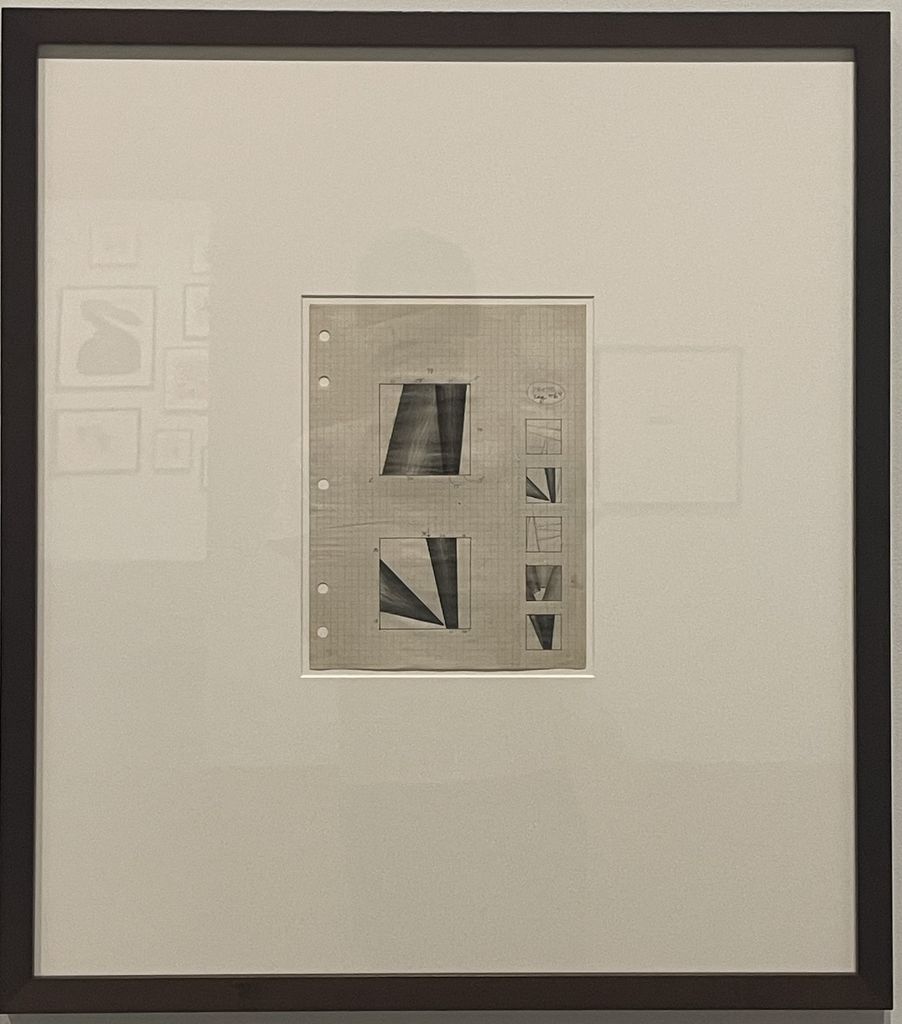

Title Unrecorded

### Closing note about visits to the Arts district.

Next time take public transportation. Street parking is enough of a hassle to run the entire experience. The other option is to pony up the cash and part in a lot, but that seems to cut against one of the nice aspects of looking at contemporary art in the gallery; it is a free activity. One of the last ones available to us as an urban public. Subsidized without government direction by the rich (or the bohemian instinct), why not commit to the bit and insist on the only cost being opportunity cost. What else would I be doing with a January Saturday afternoon in the year 2026?